# Practical Machine Learning Class Project

Peter Caya

September 21, 2016

# Preamble

The goal of this project is to take the exercise data from groupware and use that to predict the manner in which the respondents in the test dataset exercised. To do this I will train and compare three models:

1. Random forest.
2. LDA
3. Naive Bayes Classification

# Data Loading and Cleaning

The training data and testing data are loaded. Cleaning the data consists of several steps:

1. Some columns are largely empty. Columns which consist of more than 50% N/A values are removed from the training data set.
2. Several variables seem to exist as indexes or ID values. Since these aren’t relevant to the classe variable, they are removed. These variables are X,user_name,raw_timestamp_part_1,raw_timestamp_part_2,cvtd_timestamp,new_window and num_window.
3. The two operations mentioned above are then used to clean the testing data as well so that the columns in the testing data are consistent with those in the training data.

```r
set.seed(13)

# A function which returns TRUE if the number of NA values is less than portion and false if it is greater.
portion.na <- function(X, portion = .5)
{
  if( sum(is.na(X))/length(X) > portion){return(FALSE)}
  else{return(TRUE)}
}

testingData <-read.table(file = "F:/Machine Learning/Project/pml-testing.csv",header = TRUE, sep = ",",na.strings=c("NA","#DIV/0!",""))
trainingData <-read.table(file = "F:/Machine Learning/Project/pml-training.csv",header = TRUE, sep = ",",na.strings=c("NA","#DIV/0!",""))

na_acceptable <- apply(X = trainingData,MARGIN = 2 , FUN = portion.na, portion = .5)
trainingData<-trainingData[,na_acceptable]

classe_training <- trainingData%>% select_("classe")

training_indices <- createDataPartition(trainingData$classe,p = .01,list = FALSE)
trainingData <- trainingData[-60]
training_data1<- trainingData[training_indices,]
training_data2 <- trainingData[-training_indices,]
classe1 <- as.factor(classe_training[training_indices])
classe2 <-as.factor( classe_training[-training_indices])
training_data1<- cbind(training_data1,classe1)
training_data2<- cbind(training_data2,classe2)
training_data1<- training_data1 %>% rename_(classe = "classe1"  ) %>%
                                    dplyr::select(-c(X:num_window))
training_data2<- training_data2 %>% rename_(classe = "classe2"  ) %>%
                                    dplyr::select(-c(X:num_window))

names_used <- na.omit(match(names(training_data1),names(testingData)))
data_to_test <- testingData[names_used]


fitControl <- trainControl(method = "repeatedcv",
                           number = 5,
                           repeats = 5)
```

## Random Forest

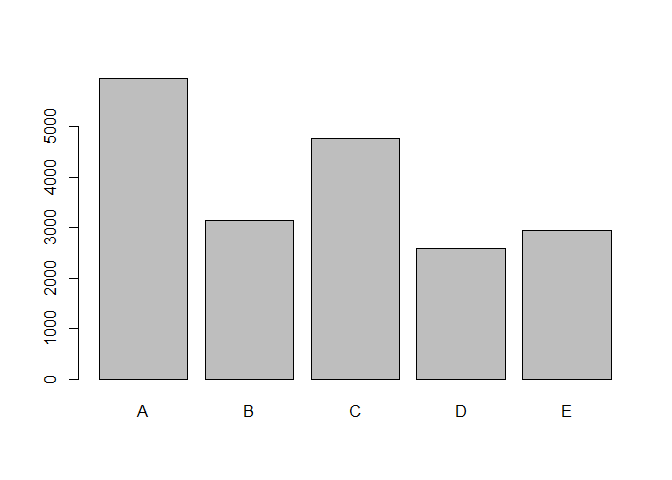

```r
RF_model <- train(data = training_data1,
                  classe~.,
                  method  = "rf" , trControl = fitControl)
RF_training2 <-predict(RF_model, training_data2,type="raw")
plot(RF_training2)
```

```r
RF_confusion <- confusionMatrix(RF_training2, training_data2$classe)
print(RF_confusion)
```

```
## Confusion Matrix and Statistics
##
##           Reference
## Prediction    A    B    C    D    E
##          A 4683  601  195  358  119
##          B  211 2090  325   76  450
##          C  387  469 2733  797  393
##          D  180  510   64 1757   83
##          E   63   89   70  195 2525
##
## Overall Statistics
##
##                Accuracy : 0.7099
##                  95% CI : (0.7034, 0.7163)
##     No Information Rate : 0.2844
##     P-Value [Acc > NIR] : < 2.2e-16
##
##                   Kappa : 0.6322
##  Mcnemar's Test P-Value : < 2.2e-16
##
## Statistics by Class:
##
##                      Class: A Class: B Class: C Class: D Class: E
## Sensitivity            0.8478   0.5560   0.8069  0.55199   0.7073
## Specificity            0.9084   0.9322   0.8724  0.94846   0.9737
## Pos Pred Value         0.7863   0.6631   0.5719  0.67733   0.8583
## Neg Pred Value         0.9376   0.8974   0.9553  0.91527   0.9366
## Prevalence             0.2844   0.1935   0.1744  0.16388   0.1838
## Detection Rate         0.2411   0.1076   0.1407  0.09046   0.1300
## Detection Prevalence   0.3066   0.1623   0.2460  0.13355   0.1515
## Balanced Accuracy      0.8781   0.7441   0.8397  0.75023   0.8405
```